# Next Generation SELECT Examples of Use

Russell Millar

```r
#NB: remotes package needs to be installed
#remotes::install_github("rbmillar/SELECT")
require(SELECT)
require(tidyverse)
```

# 1 Analysis of Clark’s covered codend haddock data

**Logistic and Richards curves are fitted. We see that the logistic is preferred**

`Clark` **is a dataframe included within the SELECT package.**

```r
#Use dtype="cc" to specify that design type is covered codend
data(Clark)
head(Clark)
```

```
##   lenclass cover codend
## 1     19.5     2      0
## 2     20.5     5      0
## 3     21.5    11      0
## 4     22.5    28      0
## 5     23.5    53      1
## 6     24.5    46      5
```

```r
cc.names=c("lenclass","cover","codend")
#Fit logistic selection curve
fitL=SELECT(Clark,cc.names,dtype="cc")
```

```
## Log-likelihood is -173.4602 at x0= -16.76 0.41
## Saturated log-likelihood is -26.15727
## Fitting SELECT model with logistic selection curves to covered codend data.
## Convergence code 0: Optimizer has converged
## Pars= -10.63315 0.303986 , Deviance= 23.43561 , #len classes= 36
```

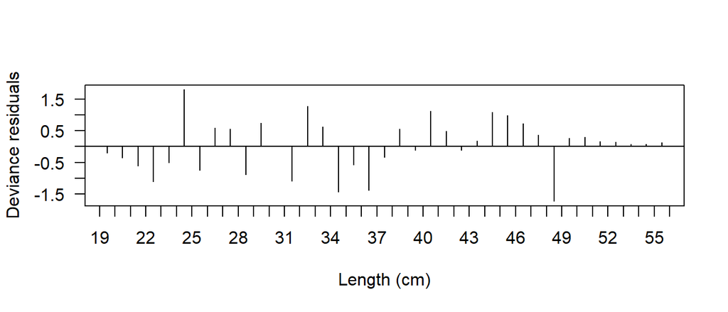

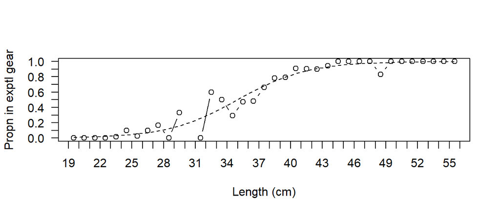

```
## Model fit:
##        null.l       model.l        full.l      Deviance Pearson.chisq
##  -242.3891493   -37.8750779   -26.1572742    23.4356074    27.1011306
##           dof   Deviance.CF    Pearson.CF
##    34.0000000     0.6892826     0.7970921
##
## Correction factors from cells with expected count > 1 :
##      Deviance Pearson.chisq           dof   Deviance.CF    Pearson.CF
##    12.7692810    13.9166294    14.0000000     0.9120915     0.9940450
```

```r
ModelCheck(fitL,minE=1,las=1)
```

```r
Estimates(fitL)
```

```
##           par      s.e.
## L50 34.979066 0.4246542
## SR   7.228046 0.5618577
```

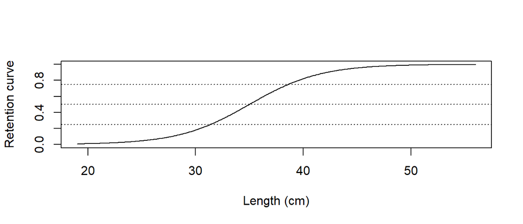

```r
PlotCurves(fitL,plotlens=seq(19,56,0.1))
```

```r
#Fit Richards selection curve
fitR=SELECT(Clark,cc.names,dtype="cc",stype="richards")
```

```
## Log-likelihood is -173.4602 at x0= -16.76 0.41 0
## Saturated log-likelihood is -26.15727
## Fitting SELECT model with richards selection curves to covered codend data.
## Convergence code 0: Optimizer has converged
## Pars= -14.49815 0.3882429 0.4855092 , Deviance= 22.30068 , #len classes= 36
```

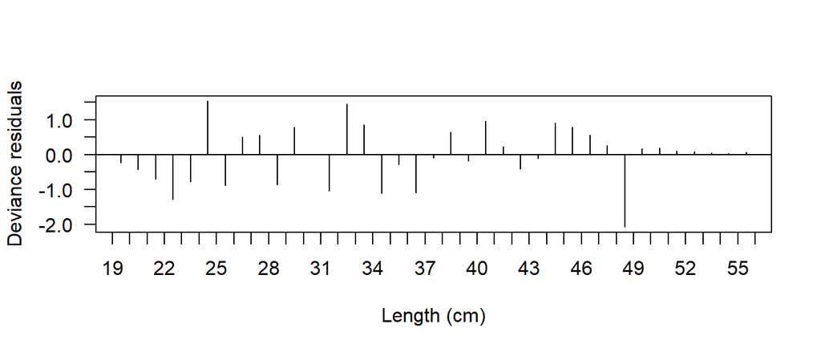

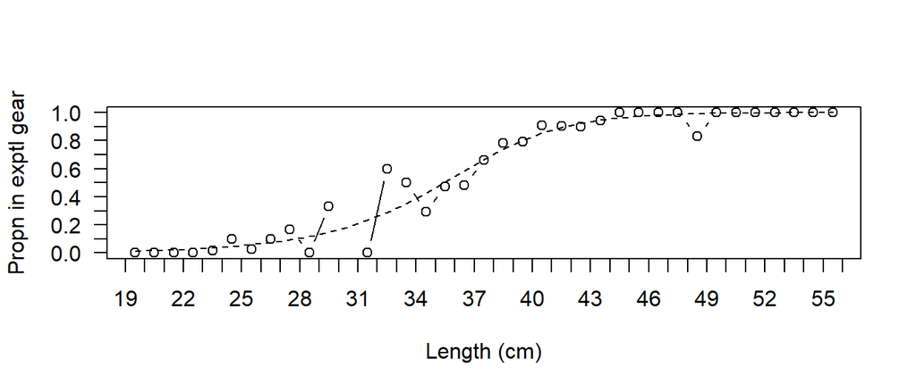

```
## Model fit:
##        null.l       model.l        full.l      Deviance Pearson.chisq
##  -242.3891493   -37.3076135   -26.1572742    22.3006786    34.9757576
##           dof   Deviance.CF    Pearson.CF
##    33.0000000     0.6757781     1.0598714
##
## Correction factors from cells with expected count > 1 :
##      Deviance Pearson.chisq           dof   Deviance.CF    Pearson.CF
##    10.9179499    11.5869505    12.0000000     0.9098292     0.9655792
```

```r
ModelCheck(fitR,minE=1,las=1)
```

```r
Estimates(fitR);
```

```
##             par      s.e.
## L25   31.826655 0.6453290
## L50   35.451142 0.5478466
## L75   38.676063 0.4111978
## SR     6.849408 0.6009597
## delta  1.625002 0.6468334
```

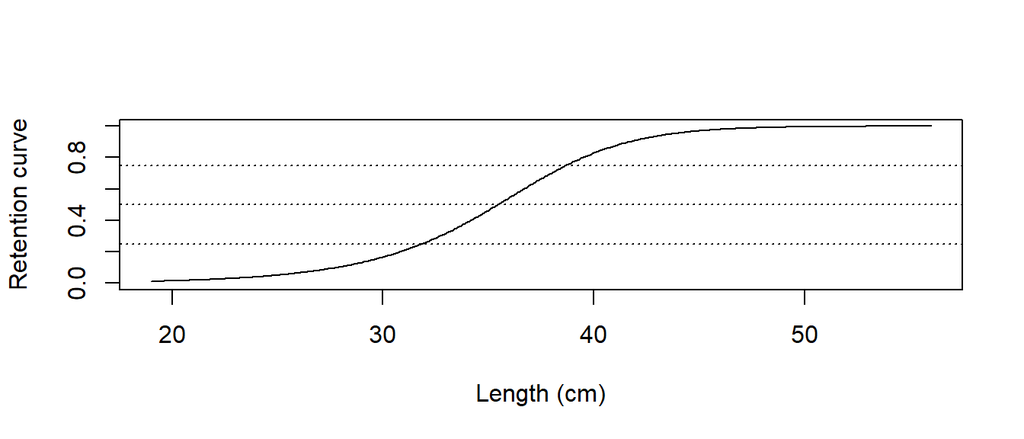

```r
PlotCurves(fitR,plotlens=seq(19,56,0.1))
```

```r
#Likelihood ratio test for H0 that logistic mode is adequate
LRTstat=2*(deviance(fitL)-deviance(fitR))
cat("\n p-value for H0:logistic is",1-pchisq(LRTstat,1))
```

```
##
##  p-value for H0:logistic is 0.131912
```

**The `ModelCheck` shows no evidence of overdispersion so we can use twice the difference in deviance as a likelihood ratio test statistic. There in no significant evidence against the logistic curve.**

# 2 Analysis of Pope’s alternate haul haddock data

```r
#Use dtype="ph" to specify that design type is paired haul
data(Pope)
head(Pope)
```

```
##   Lengths nfine nwide
## 1      24     1     0
## 2      25     1     0
## 3      26     3     0
## 4      27    14     1
## 5      28    30     5
## 6      29    49    19
```

```r
ph.names=c("Lengths","nfine","nwide")
#FIt logistic seln cure
fitL=SELECT(Pope,ph.names,dtype="ph")
```

```
## Log-likelihood is -406.4186 at x0= -24.07 0.7 0
## Saturated log-likelihood is -39.95578
## Fitting SELECT model with logistic selection curves to paired haul data.
## Convergence code 0: Optimizer has converged
## Pars= -27.64604 0.9161796 0.2935352 , Deviance= 14.83721 , #len classes= 24
```

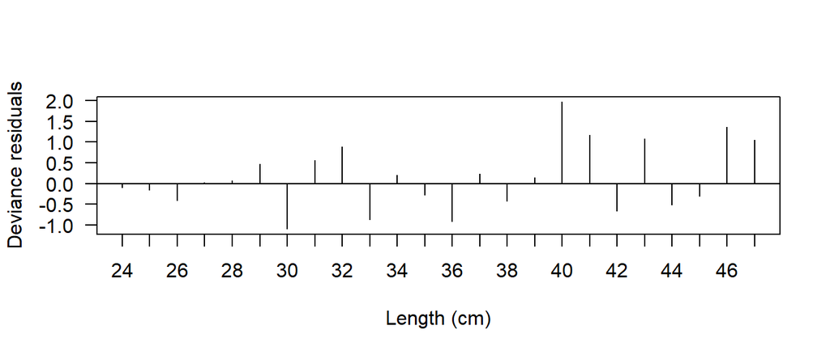

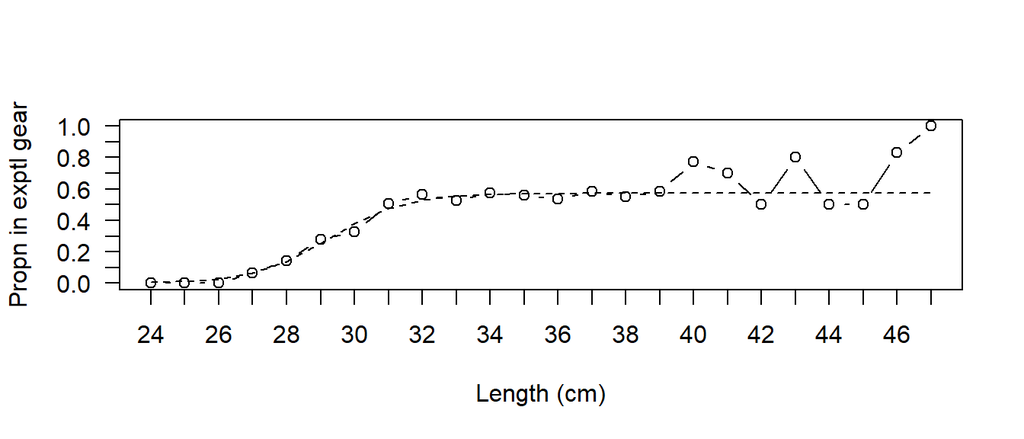

```
## Model fit:
##        null.l       model.l        full.l      Deviance Pearson.chisq
##   -87.5336729   -47.3743864   -39.9557805    14.8372118    13.7355791
##           dof   Deviance.CF    Pearson.CF
##    21.0000000     0.7065339     0.6540752
##
## Correction factors from cells with expected count > 1 :
##      Deviance Pearson.chisq           dof   Deviance.CF    Pearson.CF
##    13.5204486    12.8869874    16.0000000     0.8450280     0.8054367
```

```r
ModelCheck(fitL,minE=1,las=1)
```

```r
Estimates(fitL)
```

```
##            par       s.e.
## L50 30.1753462 0.35526986
## SR   2.3982465 0.51419914
## p    0.5728614 0.01721912
```

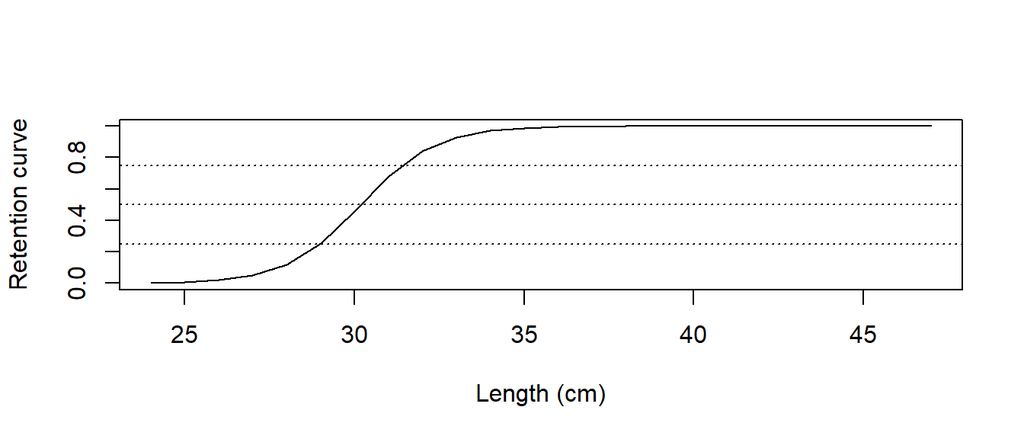

```r
PlotCurves(fitL)
```

```r
predict(fitL)
```

```
##       Length Gear1       Gear2
##  [1,]     24     1 0.003478303
##  [2,]     25     1 0.008649671
##  [3,]     26     1 0.021344887
##  [4,]     27     1 0.051701259
##  [5,]     28     1 0.119939010
##  [6,]     29     1 0.254106712
##  [7,]     30     1 0.459923996
##  [8,]     31     1 0.680382675
##  [9,]     32     1 0.841803754
## [10,]     33     1 0.930078135
## [11,]     34     1 0.970803346
## [12,]     35     1 0.988111799
## [13,]     36     1 0.995210027
## [14,]     37     1 0.998078275
## [15,]     38     1 0.999230337
## [16,]     39     1 0.999691958
## [17,]     40     1 0.999876747
## [18,]     41     1 0.999950690
## [19,]     42     1 0.999980273
## [20,]     43     1 0.999992108
## [21,]     44     1 0.999996843
## [22,]     45     1 0.999998737
## [23,]     46     1 0.999999495
## [24,]     47     1 0.999999798
```

# 3 Analysis of Pope’s alternate haul haddock data with fixed split (of 0.5)

**For fixed split, the user must specify start values for parameters of the selection curve.**

**The fixed split is specified using relative power, in this case, `rel.power=c(1,1)` since the experimental and control have the same fishing power when the split is 0.5.**

**Use `dtype=re` for `relative` (power) fits.**

```r
#Fixed split, psplit=0.5
fitR2=SELECT(Pope,ph.names,dtype="re",x0=c(-30,1),rel.power=c(1,1))
```

```
## Log-likelihood is -60.84633 at x0= -30 1
## Saturated log-likelihood is -39.95578
## Fitting SELECT model with logistic selection curves to relative data.
## Convergence code 0: Optimizer has converged
## Pars= -36.29322 1.233239 , Deviance= 36.02905 , #len classes= 24
```

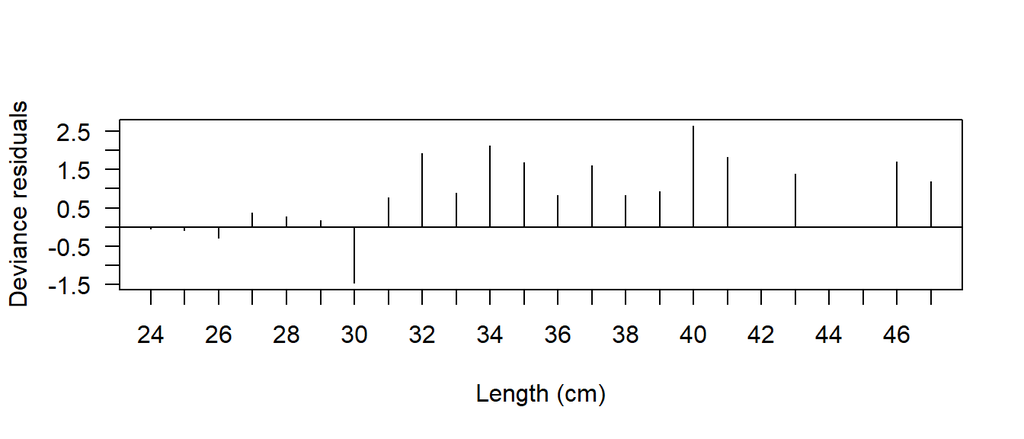

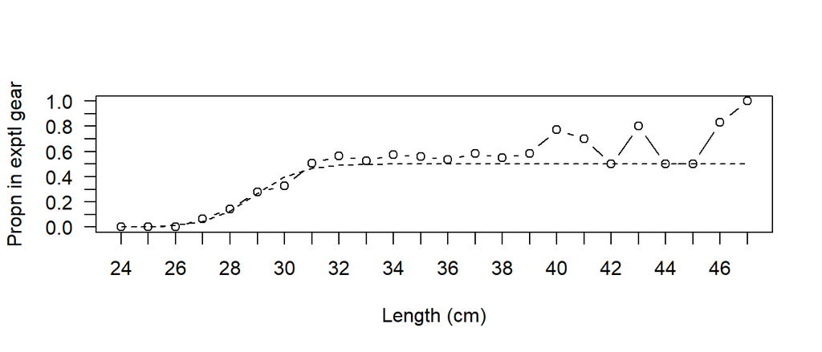

```
## Model fit:
##        null.l       model.l        full.l      Deviance Pearson.chisq
##    -87.533673    -57.970303    -39.955780     36.029045     34.683422
##           dof   Deviance.CF    Pearson.CF
##     22.000000      1.637684      1.576519
##
## Correction factors from cells with expected count > 1 :
##      Deviance Pearson.chisq           dof   Deviance.CF    Pearson.CF
##     34.409548     33.479306     17.000000      2.024091      1.969371
```

```r
ModelCheck(fitR2,minE=1,las=1)
```

```r
Estimates(fitR2)
```

```
##          par      s.e.
## L50 29.42919 0.2506562
## SR   1.78167 0.3385577
```

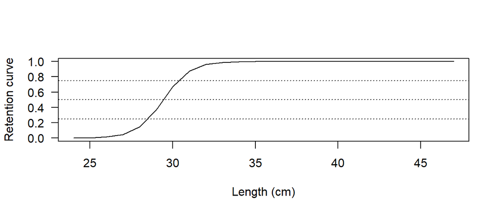

```r
PlotCurves(fitR2,las=1)
```

# 4 Relative selectivity with bootstrap and permutation test

## 4.1 Fit spline

```r
require(mgcv)
data(SimCatch)
head(SimCatch)
```

```
##   lgth n1 n2 TowID
## 1   21  0  0     1
## 2   22  0  0     1
## 3   23  1  0     1
## 4   24  0  0     1
## 5   25  0  0     1
## 6   26  1  2     1
```

```r
Vnames=c("lgth","n1","n2")
SplineFit=SplineSELECT(SimCatch,var.names=Vnames)
nsim=400 #Change to 1000 in practice
```

## 4.2 Permutation test

```r
permRsq=function(data,var.names) {
  SplineFit=SplineSELECT(data,var.names)
  summary(SplineFit)$r.sq }
ObsRsq=permRsq(SimCatch,Vnames)
cat("\nThe observed r-square is",ObsRsq,"\n")
```

```
##
## The observed r-square is 0.219588
```

```r
PermRsq=permSELECT(SimCatch,Vnames,permRsq,haul="TowID",nsim=nsim, paired=T)
```

```
##
## Starting on 400 permutations...
##   |                                                                              |                                                                      |   0%  |                                                                              |=                                                        …
##
## Permutations successfully completed
```

```r
pval=mean(ObsRsq<=PermRsq)
cat("\nThe p-value for length-independent catch share is",pval,"\n")
```

```
##
## The p-value for length-independent catch share is 0.005
```

## 4.3 Bootstrap plot

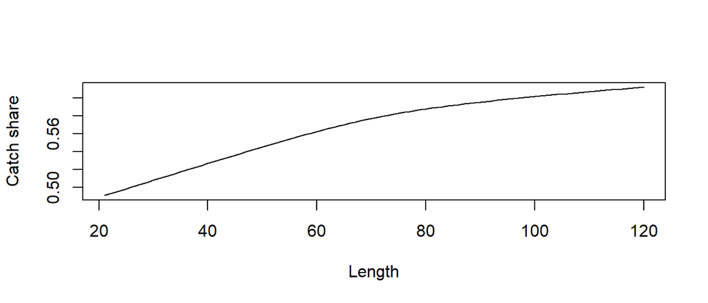

```r
lenseq=21:120
bootPredn=function(data,var.names) {
  SplineFit=SplineSELECT(data,var.names)
  predict(SplineFit,newdata=data.frame(lgth=lenseq),type="response") }
#Check that it works
preds=bootPredn(SimCatch,Vnames)
plot(lenseq,preds,type="l",xlab="Length",ylab="Catch share")
```

```r
BootPreds=bootSELECT(SimCatch,Vnames,bootPredn,haul="TowID",nsim=nsim,paired=T)
```

```
##
## Starting a 400 resamples bootstrap...
##   |                                                                              |                                                                      |   0%  |                                                                              |=                                                        …
##
## Bootstrap successfully completed
```

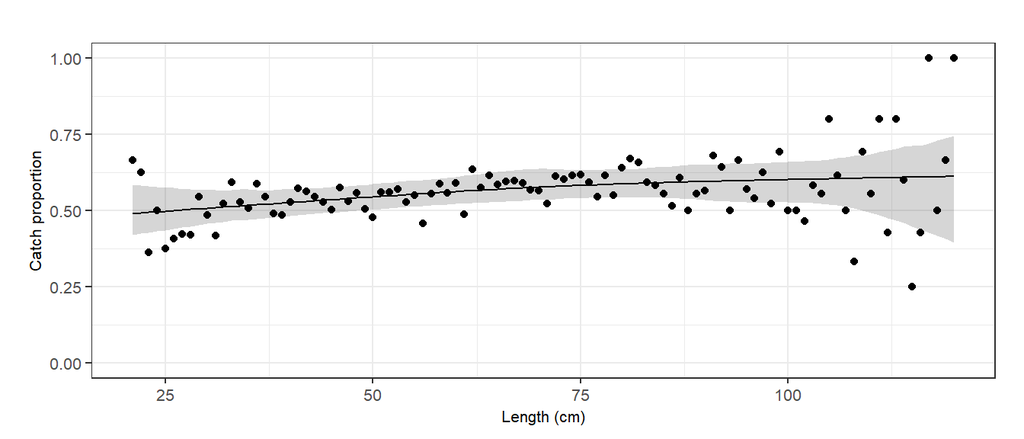

```r
Propn=SimCatch %>% group_by(lgth) %>% summarize(n1=sum(n1),n2=sum(n2))     %>% mutate(y=n2/(n1+n2))
BootPlot(BootPreds,lenseq,preds,Propn)
```

# 5 Analysis of Holt’s gillnet data

**Several alternative curve types are fitted. The bi-lognormal looks preferable, evidenced by a decrease in deviance of about 160.** **Even taking in to account the over-dispersion correction factor of about 9, this is still highly significant.** **The starting parameters for the gear with smallest mesh size need to be specified.**

```r
data(Holt)
Meshs=Holt$Meshsize
Counts=Holt$Counts
names(Counts)=c("lgth",paste0("M",Meshs))
re.names=names(Counts)
#Equal fishing power of the eight meshsizes
pwr=rep(1,8)
#Or use this for fishing power proportional to meshsize
#pwr=Meshsize

par(mfrow=c(3,2),mar=c(4.1,4.1,1,1))
fit=SELECT(Counts,re.names,dtype="re",stype="norm.loc",Meshsize=Meshs,x0=c(60,4),rel.power=pwr)
```

```
## Log-likelihood is -7040.14 at x0= 60 4
## Saturated log-likelihood is -171.3226
## Fitting SELECT model with norm.loc selection curves to relative data.
## Convergence code 0: Optimizer has converged
## Pars= 54.60056 5.148722 , Deviance= 862.9243 , #len classes= 11
```

```r
ModelCheck(fit,minE=1); Estimates(fit); PlotCurves(fit,plotlens=seq(40,90,0.1))
```

```
## Model fit:
##        null.l       model.l        full.l      Deviance Pearson.chisq
##   -1867.55849    -602.78470    -171.32257     862.92426    2577.14061
##           dof   Deviance.CF    Pearson.CF
##      75.00000      11.50566      34.36187
##
## Correction factors from cells with expected count > 1 :
##      Deviance Pearson.chisq           dof   Deviance.CF    Pearson.CF
##     778.94965     847.51159      64.00000      12.17109      13.24237
```

```
##                       par       s.e.
## Mode(mesh1)     54.600565 0.07307949
## Std dev.(mesh1)  5.148722 0.06713026
```

```r
fit=SELECT(Counts,re.names,dtype="re",stype="norm.sca",Meshsize=Meshs,x0=c(60,4),rel.power=pwr)
```

```
## Log-likelihood is -3709.341 at x0= 60 4
## Saturated log-likelihood is -171.3226
## Fitting SELECT model with norm.sca selection curves to relative data.
## Convergence code 0: Optimizer has converged
## Pars= 55.28193 4.343832 , Deviance= 772.7614 , #len classes= 11
```

```r
ModelCheck(fit,minE=1); Estimates(fit); PlotCurves(fit,plotlens=seq(40,90,0.1))
```

```
## Model fit:
##        null.l       model.l        full.l      Deviance Pearson.chisq
##   -1867.55849    -557.70325    -171.32257     772.76137    1679.84763
##           dof   Deviance.CF    Pearson.CF
##      75.00000      10.30348      22.39797
##
## Correction factors from cells with expected count > 1 :
##      Deviance Pearson.chisq           dof   Deviance.CF    Pearson.CF
##     655.25169     672.44117      63.00000      10.40082      10.67367
```

```
##                       par       s.e.
## Mode(mesh1)     55.281929 0.06986836
## Std dev.(mesh1)  4.343832 0.05269769
```

```r
#Needs wide seln curve for x0
fit=SELECT(Counts,re.names,dtype="re",stype="gamma",Meshsize=Meshs,x0=c(10,5),rel.power=pwr)
```

```
## Log-likelihood is -2721.729 at x0= 10 5
## Saturated log-likelihood is -171.3226
## Fitting SELECT model with gamma selection curves to relative data.
## Convergence code 0: Optimizer has converged
## Pars= 158.2611 0.3499446 , Deviance= 719.2918 , #len classes= 11
```

```
## Model fit:
##        null.l       model.l        full.l      Deviance Pearson.chisq
##  -1867.558490   -530.968476   -171.322572    719.291810   1629.020063
##           dof   Deviance.CF    Pearson.CF
##     75.000000      9.590557     21.720268
##
## Correction factors from cells with expected count > 1 :
##      Deviance Pearson.chisq           dof   Deviance.CF    Pearson.CF
##    635.842277    675.648540     64.000000      9.935036     10.557008
```

```
##                       par       s.e.
## Mode(mesh1)     55.032682 0.07014009
## Std dev.(mesh1)  4.402369 0.05446245
```

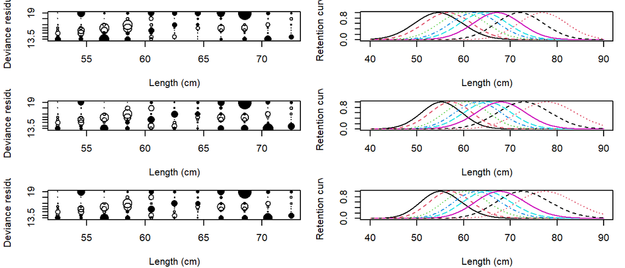

```r
ModelCheck(fit,minE=1); Estimates(fit); PlotCurves(fit,plotlens=seq(40,90,0.1))
```

```r
fit=SELECT(Counts,re.names,dtype="re",stype="logistic",Meshsize=Meshs,x0=c(-60,1),rel.power=pwr)
```

```
## Log-likelihood is -2121.887 at x0= -60 1
## Saturated log-likelihood is -171.3226
## Fitting SELECT model with logistic selection curves to relative data.
## Convergence code 0: Optimizer has converged
## Pars= -37.15865 0.5363473 , Deviance= 1571.981 , #len classes= 11
```

```r
ModelCheck(fit,minE=1); Estimates(fit); PlotCurves(fit,plotlens=seq(40,90,0.1))
```

```
## Model fit:
##        null.l       model.l        full.l      Deviance Pearson.chisq
##   -1867.55849    -957.31295    -171.32257    1571.98076    1956.95185
##           dof   Deviance.CF    Pearson.CF
##      75.00000      20.95974      26.09269
##
## Correction factors from cells with expected count > 1 :
##      Deviance Pearson.chisq           dof   Deviance.CF    Pearson.CF
##    1542.56782    1630.70802      67.00000      23.02340      24.33893
```

```
##           par      s.e.
## L50 69.280951 0.1273376
## SR   4.096645 0.1297834
```

```r
fit=SELECT(Counts,re.names,dtype="re",stype="richards",Meshsize=Meshs,x0=c(-60,1,0),rel.power=pwr)
```

```
## Log-likelihood is -2121.887 at x0= -60 1 0
## Saturated log-likelihood is -171.3226
## Fitting SELECT model with richards selection curves to relative data.
## Convergence code 0: Optimizer has converged
## Pars= -152.9469 2.12612 1.862147 , Deviance= 1466.833 , #len classes= 11
```

```r
ModelCheck(fit,minE=1); Estimates(fit); PlotCurves(fit,plotlens=seq(40,90,0.1))
```

```
## Model fit:
##        null.l       model.l        full.l      Deviance Pearson.chisq
##   -1867.55849    -904.73914    -171.32257    1466.83313    1626.10480
##           dof   Deviance.CF    Pearson.CF
##      74.00000      19.82207      21.97439
##
## Correction factors from cells with expected count > 1 :
##      Deviance Pearson.chisq           dof   Deviance.CF    Pearson.CF
##     1454.0023     1593.0720       69.0000       21.0725       23.0880
```

```
##             par      s.e.
## L25   67.739704 0.1233384
## L50   69.843837 0.1308425
## L75   71.146350 0.1603286
## SR     3.406646 0.1404361
## delta  6.437546 1.7037686
```

```r
fit=SELECT(Counts,re.names,dtype="re",stype="lognorm",Meshsize=Meshs,x0=c(log(60),0.1),rel.power=pwr)
```

```
## Log-likelihood is -1441.164 at x0= 4.09 0.1
## Saturated log-likelihood is -171.3226
## Fitting SELECT model with lognorm selection curves to relative data.
## Convergence code 0: Optimizer has converged
## Pars= 4.012147 0.08026262 , Deviance= 704.2809 , #len classes= 11
```

```
## Model fit:
##        null.l       model.l        full.l      Deviance Pearson.chisq
##  -1867.558490   -523.463042   -171.322572    704.280940   2285.670627
##           dof   Deviance.CF    Pearson.CF
##     75.000000      9.390413     30.475608
##
## Correction factors from cells with expected count > 1 :
##      Deviance Pearson.chisq           dof   Deviance.CF    Pearson.CF
##     622.44927     660.50732      64.00000       9.72577      10.32043
```

```
##                       par       s.e.
## Mode(mesh1)     54.910506 0.07053896
## Std dev.(mesh1)  4.457232 0.05826788
```

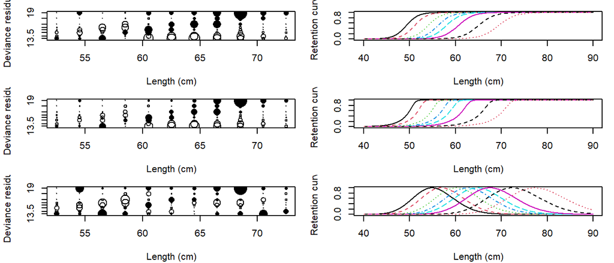

```r
ModelCheck(fit,minE=1); Estimates(fit); PlotCurves(fit,plotlens=seq(40,90,0.1))
```

```r
fit=SELECT(Counts,re.names,dtype="re",stype="binorm.sca",Meshsize=Meshs,x0=c(55,4,65,4,2),rel.power=pwr)
```

```
## Log-likelihood is -483.6976 at x0= 55 4 65 4 2
## Saturated log-likelihood is -171.3226
## Fitting SELECT model with binorm.sca selection curves to relative data.
## Convergence code 0: Optimizer has converged
## Pars= 54.67054 3.598595 80.34086 15.75706 1.490215 , Deviance= 563.8325 , #len classes= 11
```

```r
ModelCheck(fit,minE=1); Estimates(fit); PlotCurves(fit,plotlens=seq(40,90,0.1))
```

```
## Model fit:
##        null.l       model.l        full.l      Deviance Pearson.chisq
##  -1867.558490   -453.238845   -171.322572    563.832547    624.786768
##           dof   Deviance.CF    Pearson.CF
##     72.000000      7.831008      8.677594
##
## Correction factors from cells with expected count > 1 :
##      Deviance Pearson.chisq           dof   Deviance.CF    Pearson.CF
##    554.606738    612.419948     67.000000      8.277713      9.140596
```

```
##                         par       s.e.
## Mode1(mesh1)     54.6705386 0.06597046
## Std dev.1(mesh1)  3.5985947 0.06432625
## Mode2(mesh1)     80.3408633        NaN
## Std dev.2(mesh1) 15.7570589        NaN
## P(mode1)          0.8161106        NaN
```

```r
fit=SELECT(Counts,re.names,dtype="re",stype="bilognorm",Meshsize=Meshs,x0=c(4,0.2,4.2,0.1,2),rel.power=pwr)
```

```
## Log-likelihood is -1935.07 at x0= 4 0.2 4.2 0.1 2
## Saturated log-likelihood is -171.3226
## Fitting SELECT model with bilognorm selection curves to relative data.
## Convergence code 0: Optimizer has converged
## Pars= 4.002056 0.06584885 4.226652 0.2145388 2.076375 , Deviance= 545.5346 , #len classes= 11
```

```
## Model fit:
##        null.l       model.l        full.l      Deviance Pearson.chisq
##  -1867.558490   -444.089890   -171.322572    545.534636    619.161453
##           dof   Deviance.CF    Pearson.CF
##     72.000000      7.576870      8.599465
##
## Correction factors from cells with expected count > 1 :
##      Deviance Pearson.chisq           dof   Deviance.CF    Pearson.CF
##    537.678287    605.836126     68.000000      7.907034      8.909355
```

```
##                         par       s.e.
## Mode1(mesh1)     54.4738204 0.08838661
## Std dev.1(mesh1)  3.6143623 0.10510480
## Mode2(mesh1)     65.4067212 4.79566934
## Std dev.2(mesh1) 15.2099756 4.40707578
## P(mode1)          0.8885856 0.01701247
```

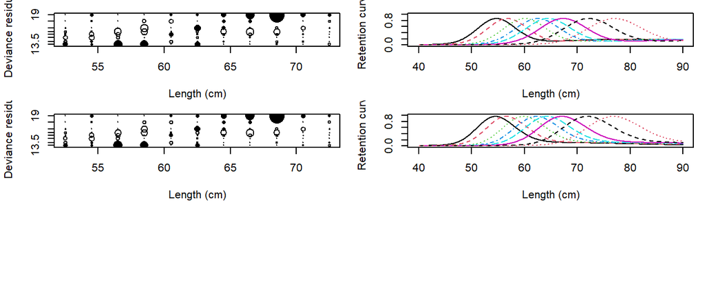

```r
ModelCheck(fit,minE=1); Estimates(fit); PlotCurves(fit,plotlens=seq(40,90,0.1))
```